# PowerPuffGenes Report

### Prolonged genes

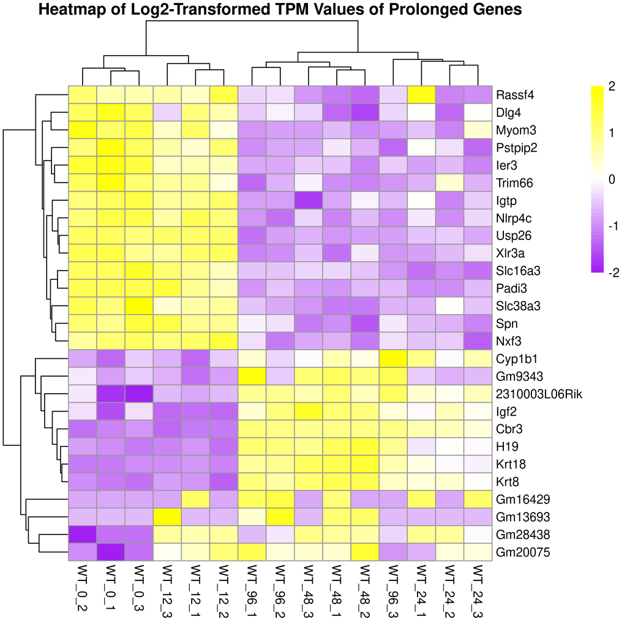

heatmap_prolonged_genes

```r
# Extract prolonged gene list from previously log transformed and filtered data
prolonged_sig_genes <- sig_log_tpm_matrix[sig_log_tpm_matrix$gene_name %in% genes_of_interest$gene_name, ]

# Remove all observations with missing data (NA)
prolonged_sig_genes <- na.omit(prolonged_sig_genes)

# Remove non numeric data for plotting heatmap
prolonged_sig_genes_numeric <- prolonged_sig_genes %>% select(-gene_id, -gene_name)

# Set rownames as the gene names to be able to visualize them in the heatmap
rownames(prolonged_sig_genes_numeric) <- prolonged_sig_genes$gene_name

# Setting custom clustering and distance functions
custom_dist <- function(x) dist(x, method = "euclidian")
custom_hclust <- function(x) hclust(x, method = "ward.D2")

# Set the scale
breaks <- seq(-2, 2, length.out = 51)

# Plot heatmap for log transformed significant genes using custom clustering and distance methods, and breaks
pheatmap(prolonged_sig_genes_numeric,
         cluster_rows = TRUE,
         cluster_cols = TRUE,
         scale = "row",
         show_rownames = TRUE,
         show_colnames = TRUE,
         main = "Heatmap of Log2-Transformed TPM Values of Prolonged Genes",
         distfun = custom_dist,
         color = colorRampPalette(c("purple", "white", "yellow"))(50),
         hclustfun = custom_hclust,
         breaks = breaks,
         filename ="results/heatmap_prolonged_genes.png"
)
```

**Heatmap of log2 transformed tpm values of prolonged genes.** A total of 27 genes had a prolonged expression trend up until last sampled time point of 96 hours after Dox treatment. Note that in this case, time points 0 and 12 grouped together, suggesting similarity in expression in initial time points. However, as time point increases, samples form a different group, with samples from 24, 48 and 96 hours.

## Circos plot

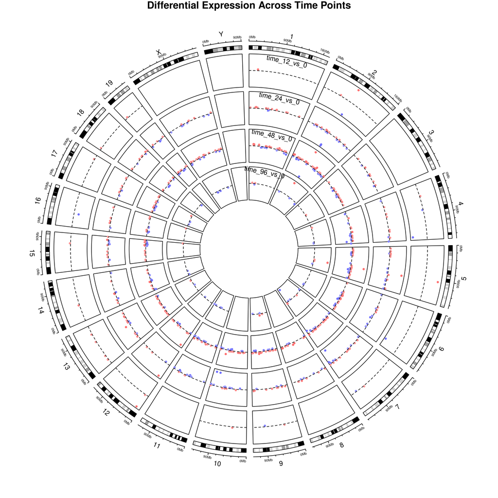

Circos plot

```r
load("results/data_files.RData")
load("results/results_counts.RData")

# --- Prep Annotations  ---
# Get gene annotations from gtf file and filter based on genes
gtf_file <- "/scratch/Shares/rinnclass/MASTER_CLASS/GENOMES/M25/gencode.vM25.annotation.gtf"
gtf_data <- rtracklayer::import(gtf_file)
gene_locations <- as.data.frame(gtf_data) %>%
  filter(type == "gene") %>%
  dplyr::select(chr = seqnames, start, end, gene_id, gene_name) %>%
  mutate(chr = as.character(chr))
# Check for 'chr' prefix
if (!all(str_detect(gene_locations$chr, "^chr"))) {
  gene_locations$chr <- paste0("chr", gene_locations$chr)
}
# Filter M and non-standard chromosomes
valid_chromosomes <- paste0("chr", c(1:19, "X", "Y")) # Specific for mouse
gene_locations <- filter(gene_locations, chr %in% valid_chromosomes)
# Remove versions of gene annotations. They can cause problems
gene_locations <- gene_locations %>%
    mutate(gene_id_base = str_remove(gene_id, "\\.\\d+$"))

# --- Merge Results and Annotations ---
# Remove versions from results
de_results_prepared <- filtered_results %>%
    mutate(gene_id_base = str_remove(gene_id, "\\.\\d+$"))
# Merge DE results with gene locations based on genes found in both datasets (inner_join)
annotated_results <- inner_join(de_results_prepared, gene_locations, by = "gene_id_base")
# Selecting and renaming relevant columns for plotting and clarity
annotated_results <- annotated_results %>%
    dplyr::select(gene_id = gene_id.x, log2FoldChange, padj, gene_name = gene_name.x,
           comparison, chr, start, end)

# --- Prepare Data for Circlize ---
# Extract all unique comparisons and select for only baseline
time_points <- unique(annotated_results$comparison)
time_points <- time_points[1:4]
# Define function to fix chromosome order (it was giving bugs)
create_sorted_chr_factor <- function() {
  # Create a correctly ordered factor for chromosomes
  chr_levels <- c(paste0("chr", 1:19), "chrX", "chrY")
  return(factor(chr_levels, levels = chr_levels))
}

# --- Make Circos Plot ---
# Set up
png("results/circos_differential_expression.png", width = 3000, height = 3000, res = 300)
circos.clear()
sorted_chrs <- create_sorted_chr_factor()     # Put chromosomes in order
circos.par(start.degree = 90, gap.degree = 2) # Overall parameters
circos.initializeWithIdeogram(
  species = "mm10",
  chromosome.index = levels(sorted_chrs)
)
point_cex <- 0.6          # Track parameters
track_height <- 0.15

# Find the global min and max log2FC values
global_max_fc <- max(abs(annotated_results$log2FoldChange), na.rm = TRUE)
message(paste("Original max log2FC:", global_max_fc))

# Add 20% margin to prevent points from being out of bounds
global_max_fc <- global_max_fc * 1.2
message(paste("Adjusted max log2FC with 20% margin:", global_max_fc))

# Define color mapping function for log2FoldChange values (like in a heatmap)
color_cap <- 2
get_color <- function(value) {
  if (is.na(value)) return("gray80")
  capped_value <- max(min(value, color_cap), -color_cap) # cap color of outliers
  intensity <- abs(capped_value) / color_cap
  intensity <- sqrt(intensity) * 0.8
  if (capped_value < 0) {
    return(rgb(1 - intensity * 0.7, 1 - intensity * 0.7, 1))  # More subtle blue
  } else if (capped_value > 0) {
    return(rgb(1, 1 - intensity * 0.7, 1 - intensity * 0.7))  # More subtle red
  } else {
    return("white")  # Zero value
  }
}

# Function to plot each comparison
plot_timepoint_comparison <- function(comparison_data, track_title) {
  if(nrow(comparison_data) > 0) {
    ylim <- c(-20, 20) # Global min/max for y-axis to keep scales consistent.
    circos.genomicTrack(
      comparison_data,
      ylim = ylim,
      track.height = track_height,
      bg.border = "black",
      panel.fun = function(region, value, ...) {
        # For each genomic region in this cell/sector
        for (i in 1:nrow(region)) {
          # Get log2FC for this specific point
          log2fc <- value$log2FoldChange[i]
          # Check if point is an extreme outlier
          if (abs(log2fc) > global_max_fc) {
            # Print information about extreme outliers (for debugging)
            message(sprintf("Extreme value: %s, chr=%s, log2FC=%.2f",
                           track_title, CELL_META$sector.index, log2fc))
          }
          # Get color for this specific point using the color function
          point_color <- get_color(log2fc)
          # Plot the individual point with its specific color
          circos.points(
            mean(c(region$start[i], region$end[i])),  # x-position (center of region)
            log2fc,                                   # y-position (log2FC value)
            col = point_color,                        # color based on log2FC
            pch = 16,                                 # solid circle
            cex = point_cex                           # point size
          )
        }

        # Add horizontal line at y=0
        circos.lines(CELL_META$xlim, c(0, 0), col = "black", lty = 2)
        # Add track title on the first sector
        if (CELL_META$sector.index == levels(sorted_chrs)[1]) {
          circos.text(
            CELL_META$xcenter,
            max(ylim) * 0.8,  # Position text inside the track area to avoid conflicts
            track_title,
            facing = "inside",
            niceFacing = TRUE,
            adj = c(0.5, 0),
            cex = 0.8
          )
        }
      }
    )
  } else {
    message(paste("No data for comparison:", track_title))
  }
}

# Plot each timepoint comparison in separate tracks
for (time_point in time_points) {
  # Filter data for this comparison
  comparison_data <- annotated_results %>%
    filter(comparison == time_point) %>%
    dplyr::select(chr, start, end, log2FoldChange)

  # Plot this timepoint comparison
  plot_timepoint_comparison(comparison_data, time_point)
}

# Plot layout
title(main = "Differential Expression Across Time Points", cex.main = 1.2)
par(xpd = TRUE)
legend_values <- seq(-color_cap, color_cap, length.out = 7)
legend_x <- 0.9
legend_y <- -1.3
color_legend_width <- 0.2
color_legend_height <- 0.02

# Draw color bar segments
for (i in 1:(length(legend_values)-1)) {
  # Calculate color for this segment
  mid_val <- (legend_values[i] + legend_values[i+1]) / 2
  segment_color <- get_color(mid_val)

  rect(
    legend_x + (i-1) * color_legend_width/(length(legend_values)-1),
    legend_y - color_legend_height,
    legend_x + i * color_legend_width/(length(legend_values)-1),
    legend_y,
    col = segment_color,
    border = NA
  )
}

# Add tick marks and labels
for (i in 1:length(legend_values)) {
  text(
    legend_x + (i-1) * color_legend_width/(length(legend_values)-1),
    legend_y - color_legend_height*1.5,
    labels = sprintf("%.1f", legend_values[i]),
    cex = 0.7,
    adj = c(0.5, 0.5)
  )
}

# Add legend title
text(
  legend_x + color_legend_width/2,
  legend_y + color_legend_height*1.5,
  "log2FoldChange",
  cex = 0.8
)
dev.off()
```

# Results

## Heatmaps

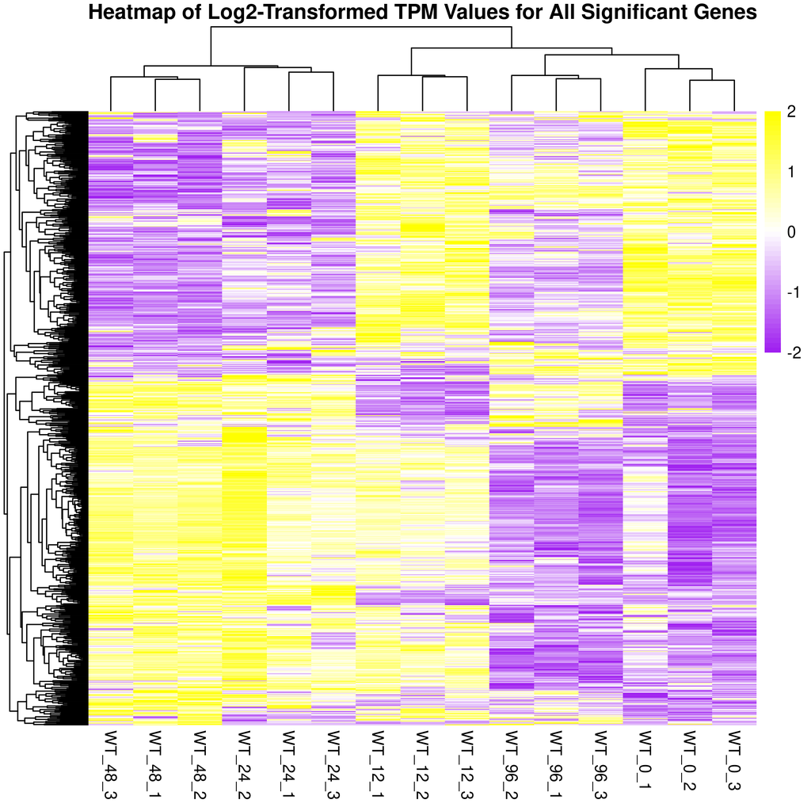

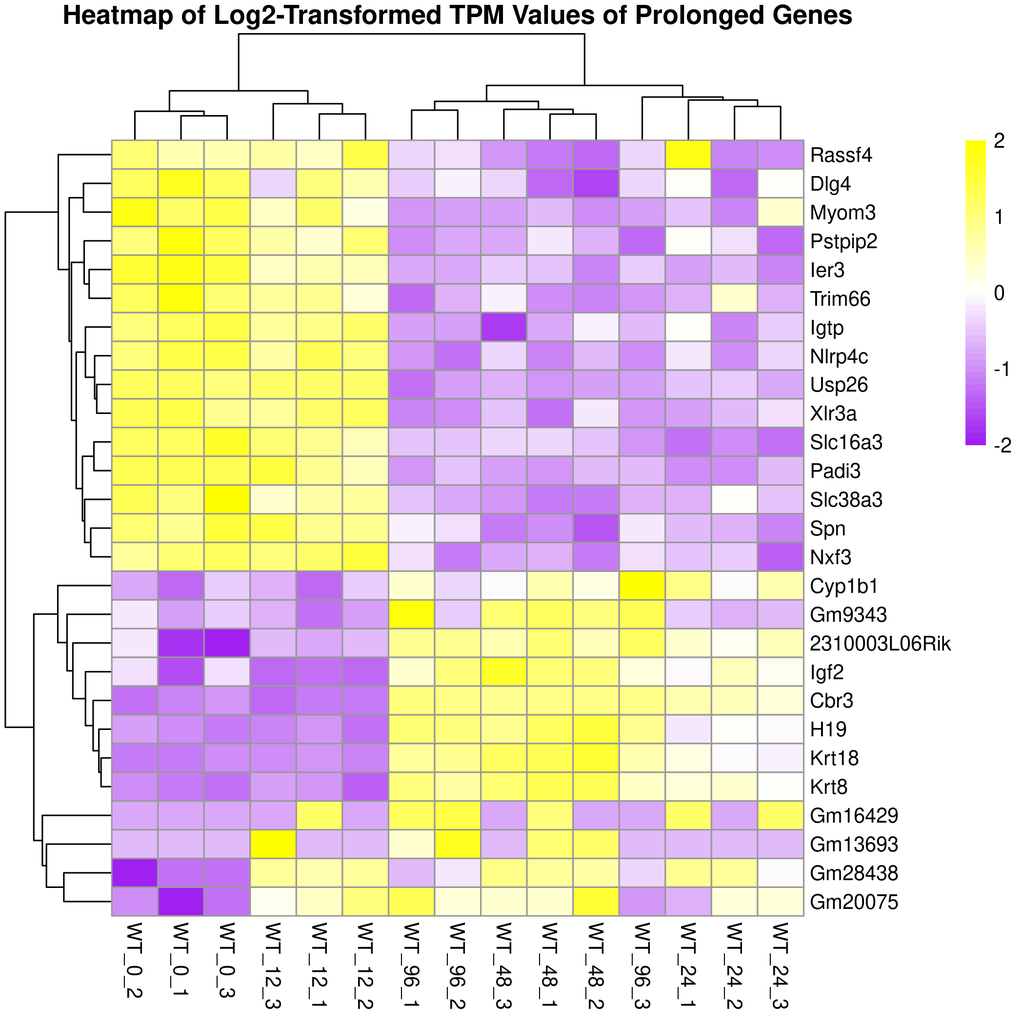

**Heatmap of log2 transformed tpm values of prolonged genes.** A total of 27 genes had a prolonged expression trend up until last sampled time point of 96 hours after Dox treatment. Note that in this case, time points 0 and 12 grouped together, suggesting similarity in expression in initial time points. However, as time point increases, samples form a different group, with samples from 24, 48 and 96 hours.

## IGV

We explored prolonged genes roles in the cell by looking at their gene ontologies (GO), and we found three genes with strong evidence of important regulatory roles in mice, H19, Usp26, and Ier3. From those three genes H19 had prolonged up regulation, while Ier3 and Usp26 had prolonged down regulation. Their prolonged change in expression suggests that these genes might be changing permanently, compromising cell integrity by changing regulatory pathways. However, additional time points should be sampled to test this hypothesis.

### H19

This gene is a long non-coding RNA (lncRNA) gene. Strong evidence suggests that this gene is involved in the control of embryonic growth. In addition, it has been found to regulate nine genes of an imprinted gene network (Monnier et al. 2013). Its prolonged up regulation after Dox treatment suggests a potential role in maintaining cellular processes related to growth and development, possibly by modulating the activity of imprinted genes that are critical for cell differentiation and tissue patterning.

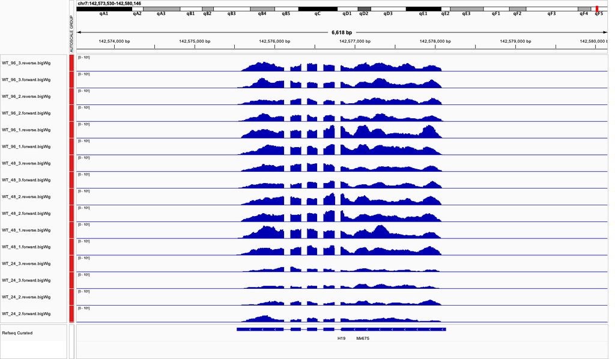

### Ier3

The immediate early response [(Ier3)](https://www.uniprot.org/uniprotkb/P46694/entry) gene may play a role in the ERK pathway for multiple cellular processes, such as growth, proliferation, differentiation, and survival. This role suggests relevance in gene regulation, making it an interesting and possibly important gene to further explore the effects of Dox treatment. Dox might be affecting the normal function of this gene by down regulating its expression at least 96 hours after treatment.

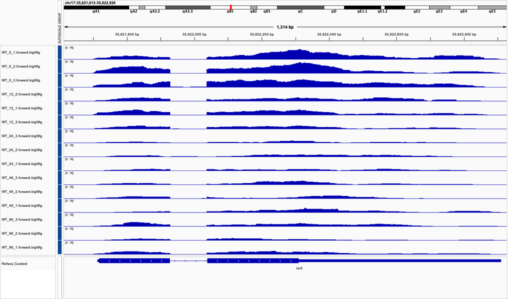

**IGV track with peaks of Ier3 gene.** Peaks represent the coverage of sequencing reads across this gene. Note that peaks are higher in the beginning at 0 hours, and they decrease as time increases. They remain low until the last time point sampled of 96 hours.

### Usp26

The [Usp26](https://www.uniprot.org/uniprotkb/Q99MX1/entry) gene has been involved in deubiquitination pathways, making it potentially relevant for gene regulation. There are many transcription factors in the cell, such as polycomb repressive complex 1 (PRC1), that are in charge of maintaining and regulating epigenetic marks in the genome (Tamburri et al. 2020). Many of these transcription factors, need ubiquitination for their function, making a deubiquitination crucial for this process as well (Mark and Rape 2021). For example, this gene has been found to be involved in somatic cell reprogramming through the K48 deubiquitination of two protein components of PRC1.

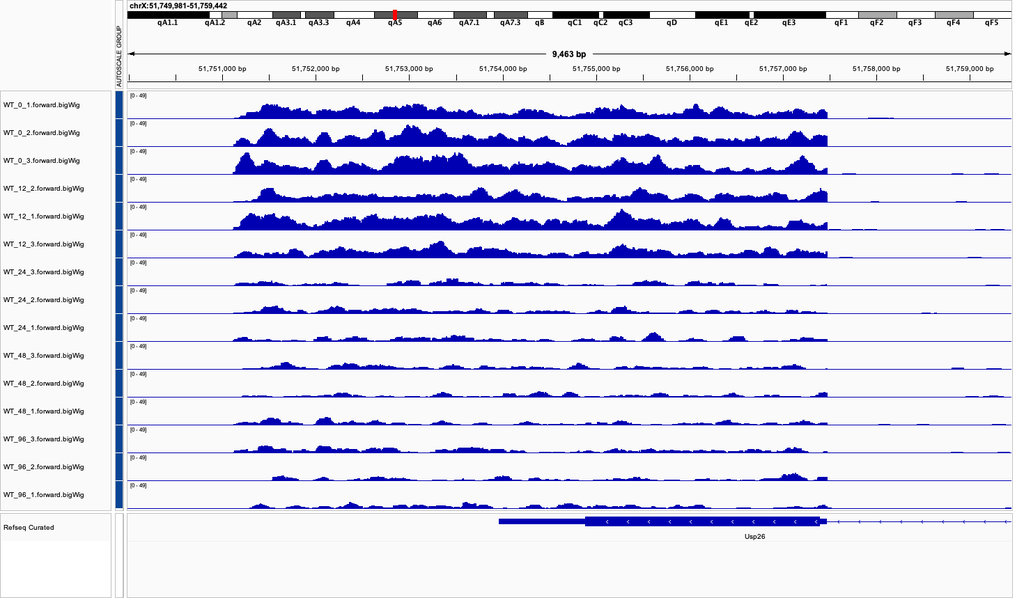

**IGV track with peaks of Usp26 gene.** Peaks represent the coverage of sequencing reads across this gene. Note that peaks are higher at 0 and 12 hours, but are lower when 24 hours are reached. They keep beung low until the last time point of 96 hours.

## Bibliography

Mark, Kevin G, and Michael Rape. 2021. “Ubiquitin‐dependent Regulation of Transcription in Development and Disease.” *EMBO Reports* 22 (4): e51078. https://doi.org/10.15252/embr.202051078.

Monnier, Paul, Clémence Martinet, Julien Pontis, Irina Stancheva, Slimane Ait-Si-Ali, and Luisa Dandolo. 2013. “H19 lncRNA Controls Gene Expression of the Imprinted Gene Network by Recruiting MBD1.” *Proceedings of the National Academy of Sciences* 110 (51): 20693–98. https://doi.org/10.1073/pnas.1310201110.

Tamburri, Simone, Elisa Lavarone, Daniel Fernández-Pérez, Eric Conway, Marika Zanotti, Daria Manganaro, and Diego Pasini. 2020. “Histone H2AK119 Mono-Ubiquitination Is Essential for Polycomb-Mediated Transcriptional Repression.” *Molecular Cell* 77 (4): 840–856.e5. https://doi.org/10.1016/j.molcel.2019.11.021.